# Damped Driven Pendulum

$$\large\frac{d^2 \phi}{dt^2} +2\beta\frac{d\phi}{dt} +\omega_o^2\sin\phi=\gamma\omega_o^2\cos(\omega t)$$

First some Python library stuff

```python
%matplotlib inline
import numpy as np
import matplotlib.pyplot as plt
import scipy.integrate as integrate
```

Now let's define the parameters for the problem

```python
gamma=.01
omega=2*np.pi
omega_o=1.5*omega
beta=omega_o/4
```

Next we need to define the derivatives

```python
def deriv(z, t):
    phi, phidot = z
    return [phidot, -2*beta*phidot-omega_o**2*np.sin(phi)+gamma*omega_o**2*np.cos(omega*t)]
```

Now we will create a vector of time values to solve the ODE and we will set an initial condition of (0,0). The we solve the ODE

```python
t = np.linspace(0, 20, 2000)
zinit = [0, 0]
z = integrate.odeint(deriv, zinit, t)
```

Time to plot the solution for $\phi$

[figure not shown]

```python
plt.plot(t,z[0:2000,0]);
plt.ylabel('$\phi$');
plt.xlabel('Time');
```

Now we crank up $\gamma$

```python
gamma=1.078
```

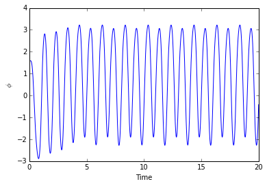

```python
t = np.linspace(0, 20, 2000)
zinit = [np.pi/2, 0]
z = integrate.odeint(deriv, zinit, t)
plt.plot(t,z[0:2000,0]);
plt.ylabel('$\phi$');
plt.xlabel('Time');
```

Now we crank up $\gamma$ some more...

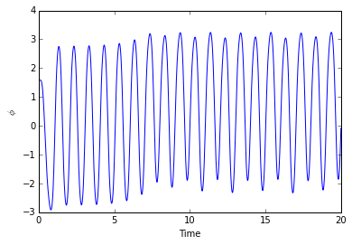

```python
gamma=1.081
t = np.linspace(0, 20, 2000)
zinit = [np.pi/2, 0]
z = integrate.odeint(deriv, zinit, t)
plt.plot(t,z[0:2000,0]);
plt.ylabel('$\phi$');
plt.xlabel('Time');
```

Zooming in

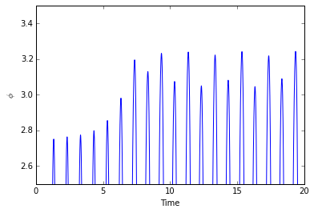

```python
plt.plot(t,z[0:2000,0]);
plt.ylim([2.5,3.5]);
plt.xlim([0,20]);
plt.ylabel('$\phi$');
plt.xlabel('Time');
```

Now we crank up $\gamma$ even more...

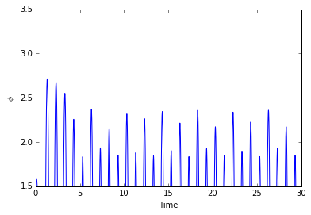

```python
gamma=1.0826
t = np.linspace(0, 30, 2000)
zinit = [np.pi/2, 0]
z = integrate.odeint(deriv, zinit, t)
plt.plot(t,z[0:2000,0]);
plt.ylim([1.5,3.5]);
plt.xlim([0,30]);
plt.ylabel('$\phi$');
plt.xlabel('Time');
```

Notice that each increase in $\gamma$ for the next period doubling was smaller. This is called a period doubling cascade.

$$\large\gamma_{n+1}-\gamma_n = \frac{1}{\delta_f} (\gamma_n-\gamma_{n-1})$$

And notice for this geometric series, that $\gamma$ goes to a fixed value as n goes to $\infty$.

That fixed value is 1.0829 and the name given to the $\delta_f$ is the Fiegenbaum Number.

So what happens to the pendulum when you go over 1.0829?

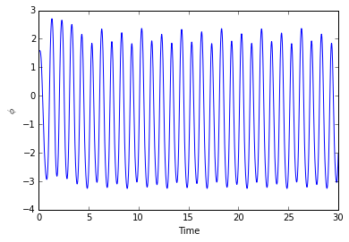

```python
gamma=1.0829
t = np.linspace(0, 30, 2000)
zinit = [np.pi/2, 0]
z = integrate.odeint(deriv, zinit, t)
plt.plot(t,z[0:2000,0]);
plt.ylabel('$\phi$');
plt.xlabel('Time');
```

And if we look longer in time, there is no sign of a repeating pattern.

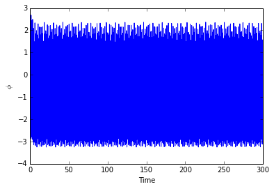

```python
gamma=1.0829
t = np.linspace(0, 300, 2000)
zinit = [np.pi/2, 0]
z = integrate.odeint(deriv, zinit, t)
plt.plot(t,z[0:2000,0]);
plt.ylabel('$\phi$');
plt.xlabel('Time');
```

Next let's look at the impact of changing the initial conditions.

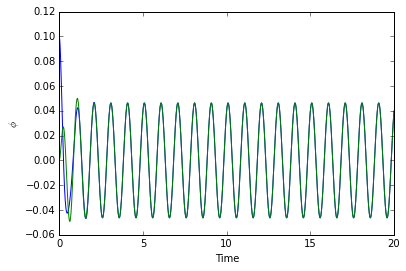

```python
gamma=.03
t = np.linspace(0, 20, 2000)
zinit = [0, 0]
z = integrate.odeint(deriv, zinit, t)
zinit = [0+.1, 0]
zz = integrate.odeint(deriv, zinit, t)
plt.plot(t,zz[0:2000,0]);
plt.plot(t,z[0:2000,0]);
plt.ylabel('$\phi$');
plt.xlabel('Time');
```

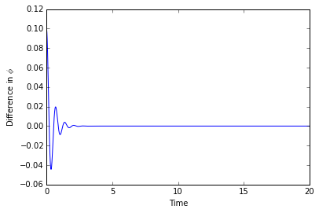

```python
plt.plot(t,zz[0:2000,0]-z[0:2000,0]);
plt.ylabel('Difference in $\phi$');
plt.xlabel('Time');
```

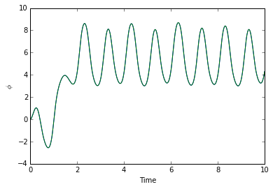

```python
gamma=1.09
t = np.linspace(0, 10, 2000)
zinit = [0, 0]
z = integrate.odeint(deriv, zinit, t)
zinit = [0+.000001, 0]
zz = integrate.odeint(deriv, zinit, t)
plt.plot(t,zz[0:2000,0]);
plt.plot(t,z[0:2000,0]);
plt.ylabel('$\phi$');
plt.xlabel('Time');
```

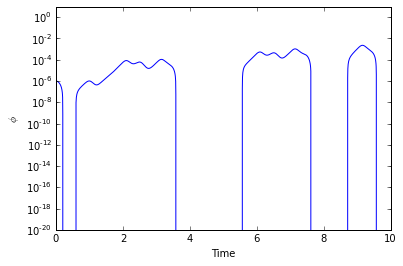

```python
plt.plot(t,zz[0:2000,0]-z[0:2000,0]);
plt.yscale('log')
plt.ylim([10**-20,10**1]);
plt.ylabel('$\phi$');
plt.xlabel('Time');
```

But this is all just fancy physics stuff right? Who cares about pendulums? We live in NC! Tell me about something I care about like Hurricanes.

[figure not shown]

So is it all just chaos above the critical $\gamma$ ?

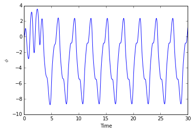

```python
gamma=1.13
t = np.linspace(0, 30, 2000)
zinit = [0, 0]
z = integrate.odeint(deriv, zinit, t)
zinit = [0+.000001, 0]
plt.plot(t,z[0:2000,0]);
plt.ylabel('$\phi$');
plt.xlabel('Time');
```

Now crank $\gamma$ up some more

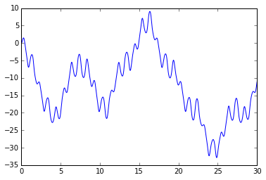

```python
gamma=1.503
t = np.linspace(0, 30, 2000)
zinit = [0, 0]
z = integrate.odeint(deriv, zinit, t)
zinit = [0+.000001, 0]
plt.plot(t,z[0:2000,0]);
```

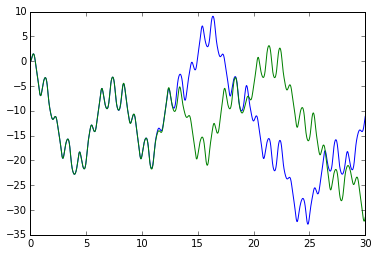

```python
gamma=1.503
t = np.linspace(0, 30, 2000)
zinit = [0+.0001, 0]
zz = integrate.odeint(deriv, zinit, t)
zinit = [0+.000001, 0]
plt.plot(t,z[0:2000,0]);
plt.plot(t,zz[0:2000,0]);
```

Next we need to think about how to see all of this varying behavior as we change the drive strength.

[figure not shown]